# Relatório

Marcus Nunes

19 de janeiro de 2018

# 1 Relatório

Vamos analisar o conjunto de dados cars, presente na memória do R. A partir de agora, cada trecho deste arquivo `.Rmd` que inicie com vai ser chamado de `chunk`. Cada `chunk` é um trecho de código do `R` que será executado e cujo output irá diretamente para o pdf final.

```r
cars
```

```
##    speed dist
## 1      4    2
## 2      4   10
## 3      7    4
## 4      7   22
## 5      8   16
## 6      9   10
## 7     10   18
## 8     10   26
## 9     10   34
## 10    11   17
## 11    11   28
## 12    12   14
## 13    12   20
## 14    12   24
```

[output cut: 36 more lines]

Este é um conjunto de dados com 50 linhas. Estas linhas ocupam muito espaço na página. Então, em vez de exibi-lo inteiro, vamos calcular algumas estatísticas a seu respeito.

```r
summary(cars)
```

```
##      speed           dist
##  Min.   : 4.0   Min.   :  2.00
##  1st Qu.:12.0   1st Qu.: 26.00
##  Median :15.0   Median : 36.00
##  Mean   :15.4   Mean   : 42.98
##  3rd Qu.:19.0   3rd Qu.: 56.00
##  Max.   :25.0   Max.   :120.00
```

**Interessante**. Encontramos o *Resumo dos Cinco Números* do conjunto de dados `cars`. Aliás, perceba como aproveitei este pequeno parágrafo para demonstrar algumas poçibilidades possibilidades de formatação de texto utilizando R Markdown.

> É possível até mesmo escrever **citações** com a linguagem!

> *Nunes, M.A. (2018)*

Mas vamos voltar à análise, pois é isto que importa aqui. Após nossas primeiras estatísticas descritivas a respeito destes dados, é interessante que façamos um gráfico relacionando distância e velocidade.

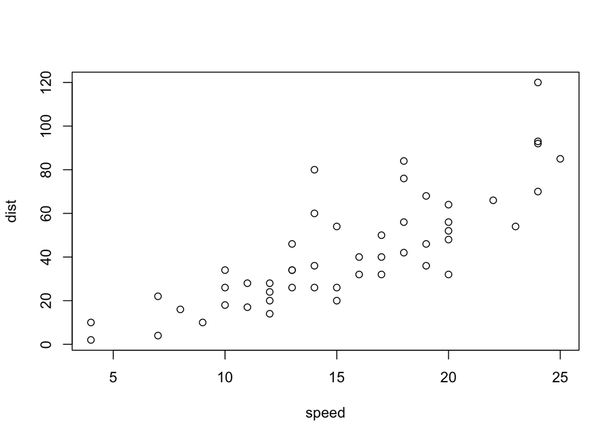

```r
plot(dist ~ speed, data=cars)
```

Note que os chunks reproduzem exatamente aquilo que o código do R deve reproduzir. Portanto, precisamos identificar corretamente os eixos do gráfico:

```r
plot(dist ~ speed, data=cars, xlab="Velocidade (mph)", ylab="Distância (pés)")
```

[output not shown]

Se colocarmos a opção `eval=FALSE`, apenas o código é exibido, sem que o gráfico seja plotado:

```r
plot(dist ~ speed, data=cars, xlab="Velocidade (mph)", ylab="Distância (pés)")
```

Eu posso inclusive fazê-la novamente em outra cor, para mostrar que a numeração é atualizada como no LaTeX tradicional:

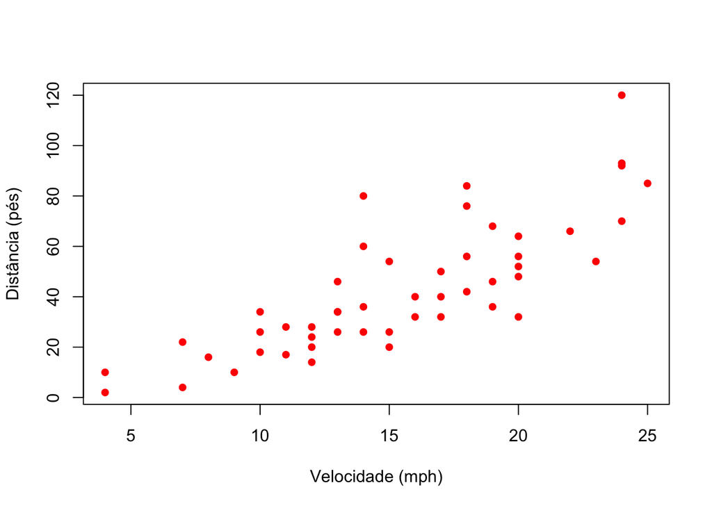

Figure 1.2: Gráfico de dispersão com os pontos em vermelho entre a distância necessária para frear completamente um carro (em pés) e sua velocidade (em milhas por hora).

Portanto, a Figura 1.2 mostra aquilo que foi prometido no parágrafo anterior. Note que estamos de fato utilizando LaTeX, pois a figura na página não ficou onde desejávamos!

(podemos consertar isto, mas este não é o escopo deste minicurso)

Além de gráficos, podemos ajustar modelos aos nossos dados. Vamos fazer uma regressão linear no conjunto de dados `cars`:

```r
ajuste <- lm(dist ~ speed, data=cars)
summary(ajuste)
```

```
##
## Call:
## lm(formula = dist ~ speed, data = cars)
##
## Residuals:
##     Min      1Q  Median      3Q     Max
## -29.069  -9.525  -2.272   9.215  43.201
##
## Coefficients:
##             Estimate Std. Error t value Pr(>|t|)
## (Intercept) -17.5791     6.7584  -2.601   0.0123 *
## speed         3.9324     0.4155   9.464 1.49e-12 ***
## ---
## Signif. codes:  0 '***' 0.001 '**' 0.01 '*' 0.05 '.' 0.1 ' ' 1
##
## Residual standard error: 15.38 on 48 degrees of freedom
## Multiple R-squared:  0.6511, Adjusted R-squared:  0.6438
## F-statistic: 89.57 on 1 and 48 DF,  p-value: 1.49e-12
```

Este output seria interessante para nós, estatísticos. Mas e o usuário comum? Como proceder para que ele veja o resultado do ajuste que fizemos, sem utilizar o output padrão do `R`? Vamos usar o pacote `knitr` e a função `kable` para isto:

```r
library(knitr)
kable(summary(ajuste)$coefficients, format="latex")
```

[output not shown]

1. tem linhas demais
2. está fora de centro
3. não tem título
4. tem muitos dígitos
5. as colunas não estão em português
6. mas olhe pelo lado bom: pelo menos aprendemos a fazer uma lista numerada no markdown

Podemos corrigir todos estes problemas de maneira razoavelmente simples. Em primeiro lugar, vamos escrever uma função que traduza o ajuste feito pela função `lm`:

```r
lm_traducao <- function(ajuste){
  traducao <- summary(ajuste)$coefficients
  colnames(traducao) <- c("Estimativa", "Erro Padrão", "t", "p-valor")
  rownames(traducao) <- c("Intercepto", "Velocidade")
  return(traducao)
}

lm_traducao(ajuste)
```

```
##            Estimativa Erro Padrão         t      p-valor
## Intercepto -17.579095   6.7584402 -2.601058 1.231882e-02
## Velocidade   3.932409   0.4155128  9.463990 1.489836e-12
```

Pronto. Agora basta criarmos uma tabela da maneira que mais nos agrada:

```r
library(kableExtra)
kable(lm_traducao(ajuste), format="html", booktabs=TRUE,
      caption="Resultado do ajuste de um modelo linear
      aos dados do pacote \\texttt{cars}.", digits=4) %>%
  kable_styling(latex_options="hold_position")
```

|  | Estimativa | Erro Padrão | t | p-valor |
| --- | --- | --- | --- | --- |
| Intercepto | -17.5791 | 6.7584 | -2.6011 | 0.0123 |
| Velocidade | 3.9324 | 0.4155 | 9.4640 | 0.0000 |

Portanto, a Tabela 1.1 ficou exatamente do jeito que imaginávamos. Note que, de modo análogo ao que fizemos com as figuras, precisamos obrigatoriamente colocar `tab:` como referência para chamar a tabela. Isto também deve ser feito para **todas** as tabelas do texto.

Agora podemos fazer o gráfico final da nossa análise, plotando os dados em conjunto com a reta ajustada. Este resultado se encontra na Figura 1.3.

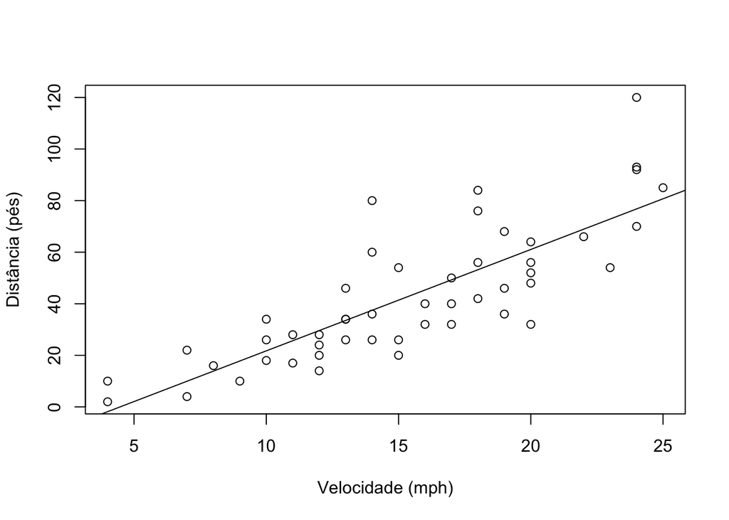

Figure 1.3: Resultado do ajuste linear entre a distância necessária para frear completamente um carro (em pés) e sua velocidade (em milhas por hora).

```r
plot(dist ~ speed, data=cars, xlab="Velocidade (mph)", ylab="Distância (pés)")
abline(ajuste)
```

Caso a Figura 1.3 tenha ficado muito grande, podemos alterar as suas dimensões, como no caso da Figura 1.4.

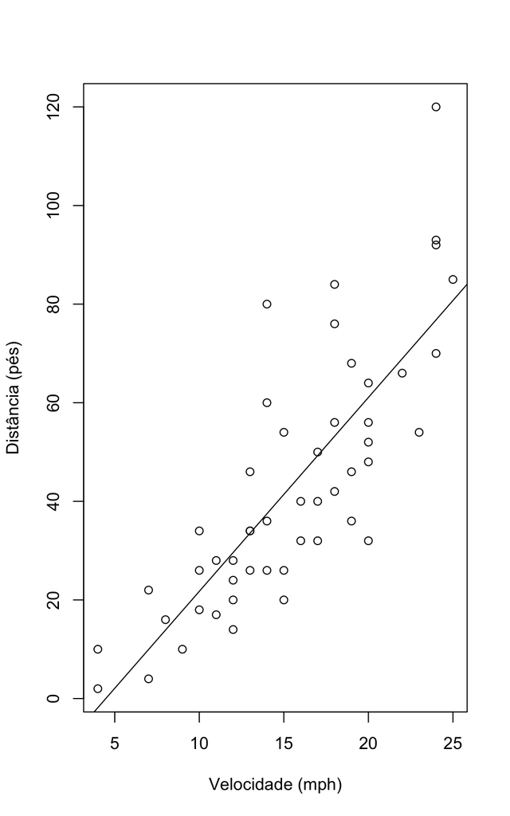

Figure 1.4: Resultado do ajuste linear entre a distância necessária para frear completamente um carro (em pés) e sua velocidade (em milhas por hora), com as dimensões alteradas.

```r
plot(dist ~ speed, data=cars, xlab="Velocidade (mph)", ylab="Distância (pés)")
abline(ajuste)
```

Quem já está acostumado com LaTeX percebe que o comportamento das figuras e tabelas do `knitr` é idêntica às figuras e tabelas do LaTeX: a posição de cada novo float é uma surpresa.

Para que este relatório fique completo, só falta a análise dos resíduos do ajuste realizado. A Figura 1.5 exibe este resultado.

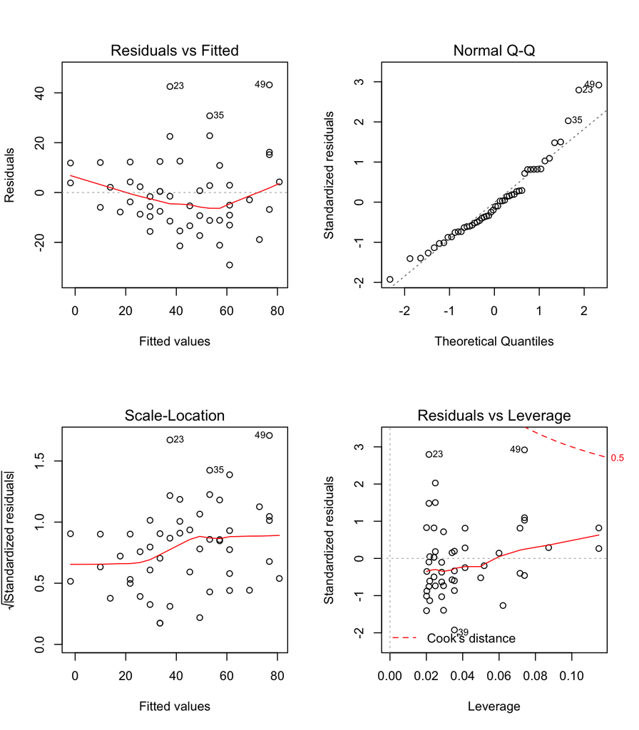

Figure 1.5: Gráficos de diagnóstico do ajuste linear entre a distância necessária para frear completamente um carro (em pés) e sua velocidade (em milhas por hora).

```r
par(mfrow=c(2,2))
plot(ajuste)
```

Note que, assim como no caso da tabela com o output do modelo de regressão, os gráficos de diagnóstico possuem os títulos e nomes dos eixos em inglês. Vou aproveitar os anos de experiência como instrutor de Matemática, Estatística e `R` e vou deixar registrada a seguinte maneira de lidar com este problema:

> A tradução destes gráficos fica como exercício para o leitor.

> *Todo autor de livro matemático quando está com preguiça de trabalhar.*

Com tudo pronto e aprendido, podemos passar agora à nossa prática.

# 2 Exercícios

Os exercícios de análise de dados a seguir foram baseados no conjunto de dados `iris`, presente na memória do `R`. Basta digitar `iris no console para ter acesso ao seu conteúdo.

Este conjunto de dados possui 150 linhas e 5 colunas. Ele possui 4 medidas a respeito de três espécies de flores, chamadas *Iris setosa*, *Iris versicolor* e *Iris virginica*. As 4 medidas disponíveis para estas flores são

- Sepal.Length: comprimento da sépala
- Sepal.Width: largura da sépala
- Petal.Length: comprimento da pétala
- Petal.Width: largura da pétala

Todas estas 4 medidas estão disponíveis para as 3 espécies de flores.

A não ser que seja especificado de outra forma no enunciado, as respostas dos exercícios devem conter o código de resolução da questão e seu output desejado.

Caso a solução de alguma questão não seja encontrada neste arquivo de exemplo, utilize o Google para procurar uma maneira de resolvê-la.

1. Utilizando o menu do RStudio, crie um novo markdown, com output em pdf, chamado `exercicios.Rmd`. Altere o cabeçalho deste arquivo, de modo que ele fique similar ao do arquivo `relatorio.Rmd`.
2. Faça o resumo dos cinco números das varíaveis quantitativas do conjunto de dados. É possível perceber alguma assimetria olhando estes resultados?
3. Rode os comandos

```r
library(GGally)
ggpairs(iris[, -5])
```

e interprete o resultado obtido.

4. Escolha as duas variáveis que se relacionam com maior intensidade e ajuste um modelo de regressão linear entre elas.
5. Exiba em uma tabela os resultados do modelo de regressão ajustado no passo anterior. Interprete o resultado obtido.
6. Crie um gráfico de dispersão relacionando estas duas variáveis. Pinte cada ponto com uma cor associada à sua espécie.
7. Faça um boxplot comparando as observações da variável `Sepal.Width` entre as três espécies de plantas.
8. Teste as hipóteses

$$\begin{align*}
H_0 &: \mu_1 = \mu_2 = \mu_3 \\
H_0 &: \mbox{pelo menos um par $\mu_i \neq \mu_j$, se $i \neq j$}
\end{align*}$$

em que $\mu_i$ é a média da variável `Sepal.Width` para os grupos

- $i = 1 \mbox{ (setosa})$
- $i = 2 \mbox{ (versicolor})$
- $i = 3 \mbox{ (virginica})$
9. Interprete o resultado do comando anterior.
10. Utilize a função `TukeyHSD` para verificar quais diferenças entre as médias são diferentes de zero de maneira significante, com nível de confiança de 95%.